# STATS_TAKEHOME_MID2

Bhavik Kollipara

11/5/2021

## QUESTION 1 (The 2012 Presidential Election By County)

### 1. Obama Votes Percentage Distribution

County Votes Table

```r
county_votes <- read.table('countyvote2012.txt', header = TRUE)
summary(county_votes)
```

```
##     STNAME            CTYNAME             TOT_POP           TOT_MALE
##  Length:100         Length:100         Min.   :    487   Min.   :    248
##  Class :character   Class :character   1st Qu.:   8490   1st Qu.:   4652
##  Mode  :character   Mode  :character   Median :  26035   Median :  12736
##                                        Mean   : 142468   Mean   :  69843
##                                        3rd Qu.:  67484   3rd Qu.:  33476
##                                        Max.   :4167947   Max.   :2059860
##    TOT_FEMALE          OBAMA            ROMNEY
##  Min.   :    239   Min.   :    29   Min.   :   188
##  1st Qu.:   4061   1st Qu.:  1196   1st Qu.:  2114
##  Median :  12912   Median :  3510   Median :  5883
##  Mean   :  72625   Mean   : 27700   Mean   : 23972
##  3rd Qu.:  34008   3rd Qu.: 11012   3rd Qu.: 13035
##  Max.   :2108087   Max.   :512008   Max.   :654835
```

```r
# Calculating Obama Votes Percentage
county_votes['ObamaVotes_percent'] <- county_votes['OBAMA']/(county_votes['OBAMA']+county_votes['ROMNEY']) *100

head(county_votes)
```

```
##          STNAME            CTYNAME TOT_POP TOT_MALE TOT_FEMALE OBAMA ROMNEY
## 1  Pennsylvania Northampton County  300813   147711     153102 65014  59242
## 2          Ohio       Henry County   27816    13667      14149  5513   8111
## 3 Massachusetts     Hampden County  470690   227373     243317  7288   6870
## 4          Ohio       Union County   54277    25953      28324  8546  15947
## 5          Iowa       Adair County    7228     3553       3675  1788   2110
## 6     Tennessee    Crockett County   14601     6967       7634  1669   3782
##   ObamaVotes_percent
## 1           52.32262
## 2           40.46536
## 3           51.47620
## 4           34.89160
## 5           45.86968
## 6           30.61824
```

*Distribution of Obama Votes Percentage across the counties can be given by plottig a density function across the obamavotes_percentage column.

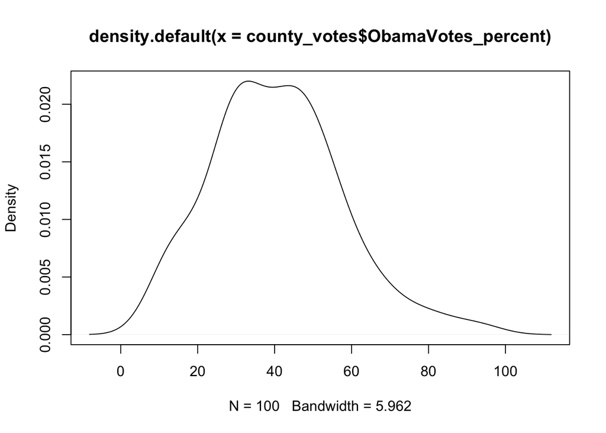

```r
plot(density(county_votes$ObamaVotes_percent))
```

*This seems like the data points of ObamaVotes_percent follows as Normal Distribution based on above Density Plot. We canuse qq plots to it.*

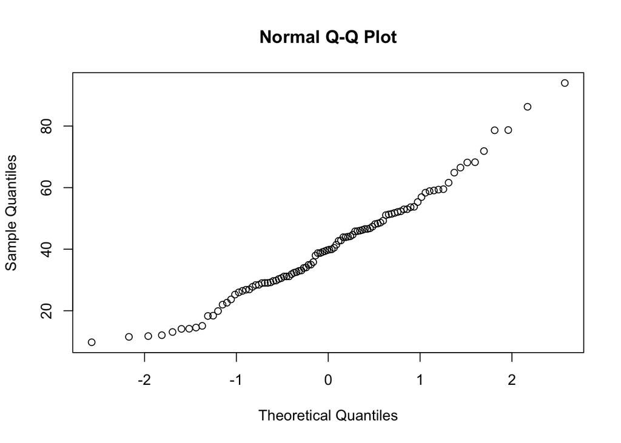

```r
qqnorm(county_votes$ObamaVotes_percent)
```

*Based on the QQplot, it seems like the obamavotes_percent distribution follow approximately normal. distribution.*

To get summary statistics of the ObamaVotes_percent.

```r
summary(county_votes$ObamaVotes_percent)
```

```
##    Min. 1st Qu.  Median    Mean 3rd Qu.    Max.
##   9.764  29.045  39.760  40.603  51.342  93.984
```

*From the above statistics, we can say that the distribution of Obama_vote_percent have a Mean 0f 40.603% with standard deviation of 17.044%. Maximum percentage of Obama’s votes is 93.984% whereas minimum is 9.764%.*

### 2. Counties Won ( Obama vs Romney)

```r
county_votes['votes'] <- as.integer(county_votes['OBAMA']>county_votes['ROMNEY'])

Obama_won <- sum(county_votes['votes']==TRUE)

Obama_won
```

```
## [1] 27
```

```r
Romney_won= 100-Obama_won

Romney_won
```

```
## [1] 73
```

*27 counties are won BY OBAMA* *73 Counties are won BY ROMNEY*

Who won more counties among the whole population counties ?

*Let’s take obama_prop= obama/counties won by obama + counties won by romney and romney_prop= romney/counties won by obama + counties won by romney.

*Null Hypothesis (H0): obama_prop<=0.5, Alternate Hypothesis(H1): obama_prop > 0.5*

*Let’s do Binomial test as the no of counties(votes) won are boolean(win or lose). (Right-tailed test)

- Here we assume that the sample is an IID sample.

```r
p= 1-pbinom(27-1,100,0.5)

p
```

```
## [1] 0.9999992
```

*Based on the p-value=0.999, we can say the data is consistent with the NULL Hypothesis and thus we accept it.we have higher evidence that obama’s vote proportion is less than 0.5*

Confidence Interval of 99% for the proportion statistic.

```r
prop <- 0.27
q<- qnorm(0.995)
q
```

```
## [1] 2.575829
```

```r
#lower limit
prop - q*sqrt(prop*(1-prop)/100)
```

```
## [1] 0.1556436
```

```r
# upper limit
prop + q*sqrt(prop*(1-prop)/100)
```

```
## [1] 0.3843564
```

*The CI here is (0.15,0.38) which gives us the extra evidence that the hypothesis choosen is true. That is the proportion of Obama votes is less than 0.5*

### 3. More votes per County. (OBAMA VS ROMNEY)

```r
muo=mean(county_votes$OBAMA)
mur=mean(county_votes$ROMNEY)
muo
```

```
## [1] 27700.02
```

```r
mur
```

```
## [1] 23972.18
```

*Based on this (muo>mur), Obama won more votes per county*

*Here we have a sample of 100, which is large enough to consider Central-Limit Theorm to perform the test.*

*Let’s take H0: muo-mur<=0, H1: muo-mur>0*

```r
diff <- county_votes$OBAMA-county_votes$ROMNEY
mu <- mean(diff)
mu
```

```
## [1] 3727.84
```

```r
n <- length(diff)
n
```

```
## [1] 100
```

```r
q<-qnorm(0.975)
q
```

```
## [1] 1.959964
```

```r
se <- sd(diff)
se
```

```
## [1] 35941.39
```

```r
p <- 1-pnorm(mu,0,se/sqrt(n))
p
```

```
## [1] 0.1498214
```

```r
#lower-limt
mu-1.96*se/sqrt(n)
```

```
## [1] -3316.673
```

```r
#upper-limit
mu+1.96*se/sqrt(n)
```

```
## [1] 10772.35
```

*Here p-value=0.15, which mean the data is consistent with the Null Hypothesis (Not statistically significant to reject H0)*

*CI of 95% is (-3316,10772) which includes 0, so we don’t have strong evidence to specify who won more votes over the whole population.*

*Though romney won more counties from the previous question, we can’t say that one gets more votes than the other*

## QUESTION 2. (Flag Priming)

### 1. MANYLABS_US

```r
#read data
many_labs <- read.table('manylabs.txt', header=TRUE)
# data points of only us people
many_labs_us <-many_labs[many_labs$us_or_international==0,]
many_labs_us <-many_labs_us[,c('flagdv','flagGroup')]
many_labs_us <-na.omit(many_labs_us)
head(many_labs_us)
```

```
##   flagdv flagGroup
## 1  3.250         0
## 2  3.625         1
## 3  3.250         1
## 5  4.750         0
## 6  2.625         0
## 7  3.250         1
```

**Informative graphs of the Data**

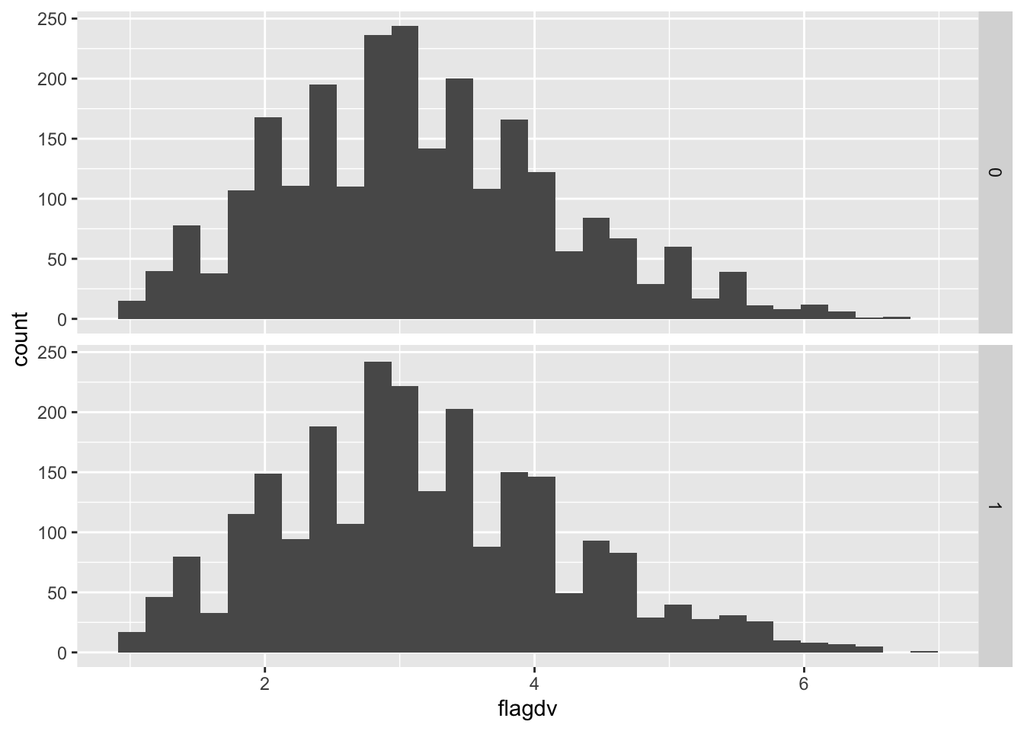

```r
library(ggplot2)
#Histogram
ggplot(many_labs_us, aes(x=flagdv))+geom_histogram()+facet_grid(flagGroup~.)
```

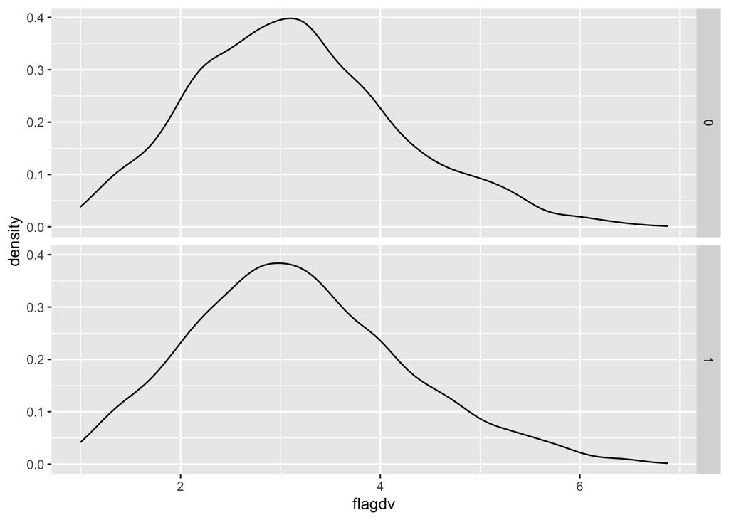

```r
#BOX-Plots
ggplot(many_labs_us, aes(x=flagdv))+geom_density()+facet_grid(flagGroup~.)
```

### 2. Populations and parameters of interest

Here the two populations we define are the participants within the flag-prime(flagGroup=1) condition and the others within the Control Group (flagGroup=0).

The parameters of interest are the mean of flagdv values of each population. Let the mean of flag-prime group is $mu1$ and mean of control group is $mu0$.

### 3. Hypothesis for one-tailed test

Let $delta$ = $mu0$-$mu1$

Null Hypothesis (H0) : $mu0$-$mu1$>=0 and Alternate Hypothesis(H1): $mu0$-$mu1$<0

### 4. Statistic test

As we deal with a very large sample here, we can assume the population distribution to be Normal. And because it’s a two sample one-tailed test, we can use *Welch’s T-test* based on our assumptions.

### 5. Welch’s t-test

```r
t.test(data=many_labs_us,flagdv~flagGroup,alt='less')
```

```
##
##  Welch Two Sample t-test
##
## data:  flagdv by flagGroup
## t = -0.87886, df = 4883.3, p-value = 0.1898
## alternative hypothesis: true difference in means between group 0 and group 1 is less than 0
## 95 percent confidence interval:
##        -Inf 0.02310113
## sample estimates:
## mean in group 0 mean in group 1
##        3.146832        3.173326
```

### 6. 99.5% Confidence Interval

```r
t.test(data=many_labs_us,flagdv~flagGroup,conf.level=0.995)
```

```
##
##  Welch Two Sample t-test
##
## data:  flagdv by flagGroup
## t = -0.87886, df = 4883.3, p-value = 0.3795
## alternative hypothesis: true difference in means between group 0 and group 1 is not equal to 0
## 99.5 percent confidence interval:
##  -0.11115357  0.05816534
## sample estimates:
## mean in group 0 mean in group 1
##        3.146832        3.173326
```

### 7. Conclusion

The hypothesised effect is not replicated with the data. the p-value=0.1898 which is not statistically significant and thus we have little evidence that the participants in the treatement group are more conservative compared to the participants in the control group. the CI also includes 0 which say it has support for both the Control and flag-prime treatment group.